# COSC-523: Lab 06

**Daniel Carter**

[Notebook Link](https://colab.research.google.com/drive/1TXht9mw8PRTZncptMoEdx7CehZ8o6KAD#scrollTo=1HW_tpnTHbiQ)

## Getting Started

Follow the instructions below to copy this notebook and to perform some initial setup.

1. Copy this notebook by selecting `File > Save a copy in Drive`.
2. A new window should open for the copied notebook. Move the new notebook to your course folder in Google Drive by selecting `File > Move` and then selecting the desired folder.
3. Update the name of the notebook by removing "Copy of" and replacing "Username" with your actual username.
4. Update the first cell in the notebook by specifying your course number (423 or 523) and by replacing "**Student Name**" with your actual name.
5. Do not edit the line that says `PLACEHOLDER_FOR_NOTEBOOK_LINK`. This will be used by the [Notebook Renderer](https://colab.research.google.com/drive/1CJTipys46ldZxJFwnt7XbdjQUfkmoXeU?usp=sharing) tool to insert a link to your Colab notebook.
6. Enable link sharing for your notebook.

# Part 1: Understanding the Fundamentals of Image Segmentation and U-Net

Instructions:

- What is U-Net?  
  Describe the architecture of U-Net and how it is designed for image segmentation. Discuss the role of the encoder and decoder, as well as skip connections.
- What is the difference between semantic segmentation and instance segmentation?
- What loss function is typically used in image segmentation tasks?
- What is the role of convolutional layers in segmentation tasks?
- Explain how convolutional layers help extract features from images and contribute to pixel-wise classification in segmentation tasks.
- What is U-Net?
  - U-Net is a convolutional neural network designed for biomedical image segmentation, featuring a U-shaped architecture with an encoder for feature extraction and a decoder for upsampling to achieve precise pixel-wise classification.
- Describe the architecture of U-Net and how it is designed for image segmentation. Discuss the role of the encoder and decoder, as well as skip connections.
  - U-Nets architecture includes a contracting encoder and an expanding decoder. The encoder uses convolutional and max-pooling layers to extract features and reduce spatial dimensions, capturing contextual information. The decoder upsamples features via transposed convolutions to restore spatial resolution for accurate segmentation. Skip connections concatenate encoder features with decoder layers, preserving detailed spatial information and improving gradient flow for pixel-wise predictions.
- What is the difference between semantic segmentation and instance segmentation?
  - Semantic segmentation labels each pixel with a class without distinguishing object instances (e.g., all "tree" pixels share one label). Instance segmentation identifies and segments each object instance separately, assigning unique labels to individual objects of the same class (e.g., "tree1," "tree2").
- What loss function is typically used in image segmentation tasks?
  - The Intersection over Union (IoU) loss, also known as Jaccard loss, or cross-entropy loss is commonly used in image segmentation. IoU loss optimizes the ratio of intersection to union between predicted and ground-truth masks, while cross-entropy measures pixel-wise classification error, often combined for handling class imbalance.
- What is the role of convolutional layers in segmentation tasks?
  - Convolutional layers extract spatial features from images, enabling the network to identify patterns and textures essential for region classification in segmentation tasks.
- Explain how convolutional layers help extract features from images and contribute to pixel-wise classification in segmentation tasks.
  - Convolutional layers use filters to detect low-level features (e.g., edges) in early layers and high-level features (e.g., objects) in deeper layers, generating feature maps that encode hierarchical patterns. In segmentation tasks, these feature maps are processed through the network (e.g., U-Net’s encoder-decoder) to produce dense outputs, enabling pixel-wise classification by assigning class labels to each pixel based on learned spatial and contextual features.

# Part 2A: Implementing Transfer Learning

Instructions:

Use the Transfer Learning architecture to perform image classification on the Oxford Pets dataset, which contains images of cats and dogs with the following changes:

1. Instead of using MobileNetv2, use the following pre-trained models: ResNet50, EfficientNetB0, VGG16, and InceptionV3. Keep other parameters the same. You don't need to copy the whole code again and again for each pre-trained model. You can copy the code from the module and then make changes, and run it with different models. The code that you will submit will have the last model on it: InceptionV3
2. For each pre-trained model, record the validation error. You can create a list manually
3. Which one gave the worst and the best performance? What was the validation error? Which one of the pretrained models made the wrong classification prediction? Why do you think some pre-trained models worked better and why did some do worse? Which models predicted the test images as dog/cat?

# Part 2B: Visualizing different pre-trained models on the Oxford Pets Dataset

Instructions: Write a Python script to visualize the different validation accuracies of different pre-trained models using a bar chart in Matplotlib.

Instructions:

- Use plt.figure(figsize=(8, 5)) to define the plot size for better readability.
- Use plt.bar(x, y, color=[...]) to create a bar chart, where: x is a list of model names. y contains their accuracy values.
- Assign different colors to each bar for better distinction.
- Label the X-axis as "Model".
- Label the Y-axis as "Accuracy".
- Add the Title:"Accuracy of Different Pre-trained Models"
- Use plt.ylim(0, 1) to ensure that accuracy values remain within the range 0 to 1.
- Use plt.xticks(rotation=20) to rotate the labels by 20 degrees, making them easier to read
- Display the Plot:

```python
#Load necessary modules
import numpy as np
import matplotlib.pyplot as plt
import os
from PIL import Image
import keras
from keras.models import Model
from keras.layers import Conv2D, MaxPooling2D, Input, Conv2DTranspose, Concatenate, BatchNormalization, UpSampling2D
from keras.layers import  Dropout, Activation
from keras.optimizers import Adam, SGD
from tensorflow.keras.layers import LeakyReLU
from keras.callbacks import ModelCheckpoint, ReduceLROnPlateau, EarlyStopping
from keras import backend as K
from keras.utils import plot_model
import tensorflow as tf
import glob
import random
import cv2
from random import shuffle
from tensorflow.keras.preprocessing.image import ImageDataGenerator
import zipfile
```

```python
#Load images from same location as transfer learning notebook. Preprocess them
# Download dataset
dataset_path = tf.keras.utils.get_file(
    "cats_and_dogs_filtered.zip",
    "https://storage.googleapis.com/mledu-datasets/cats_and_dogs_filtered.zip"
)

# Manually extract the dataset
extract_path = os.path.join(os.path.dirname(dataset_path), "cats_and_dogs_filtered")
with zipfile.ZipFile(dataset_path, 'r') as zip_ref:
    zip_ref.extractall(os.path.dirname(dataset_path))

# Print extracted folder contents
print("Extracted to:", extract_path)
print("Contents:", os.listdir(extract_path))
```

```
Extracted to: /root/.keras/datasets/cats_and_dogs_filtered
Contents: ['validation', 'train', 'vectorize.py']
```

```python
train_dir = os.path.join(extract_path, "train")
validation_dir = os.path.join(extract_path, "validation")

print("Train directory exists:", os.path.exists(train_dir))
print("Validation directory exists:", os.path.exists(validation_dir))
```

```
Train directory exists: True
Validation directory exists: True
```

```
Number of training images: 2000
Number of validation images: 1000
```

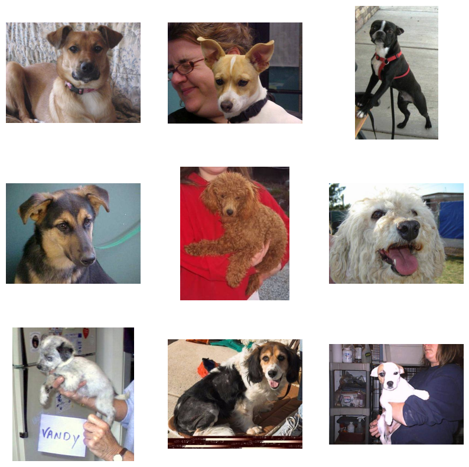

```python
#Visualize some of the images
train_imgs = glob.glob(os.path.join(train_dir, '*', '*.jpg'))
validation_imgs = glob.glob(os.path.join(validation_dir, '*', '*.jpg'))

print("Number of training images:", len(train_imgs))
print("Number of validation images:", len(validation_imgs))

#Plot some of the training images
plt.figure(figsize=(10, 10))
for i in range(9):
    plt.subplot(3, 3, i + 1)
    img = cv2.imread(train_imgs[i])
    img = cv2.cvtColor(img, cv2.COLOR_BGR2RGB)
    plt.imshow(img)
    plt.axis('off')
plt.show()
```

```python
#ImageDataGenerator
train_datagen = ImageDataGenerator(rescale=1./255)
val_datagen = ImageDataGenerator(rescale=1./255)

#Split into train/test data
train_generator = train_datagen.flow_from_directory(
        train_dir,
        target_size=(150, 150),
        batch_size=32,
        class_mode='binary',
        seed=15)

validation_generator = train_datagen.flow_from_directory(
        validation_dir,
        target_size=(150, 150),
        batch_size=32,
        class_mode='binary',
        seed=15)
```

```
Found 2000 images belonging to 2 classes.
Found 1000 images belonging to 2 classes.
```

```python
#lists for models and accuracies
models = []
accuracies = []

#load each model with pretrained weights and without the classification layer
base_model_resnet50 = tf.keras.applications.ResNet50(weights='imagenet', include_top=False, input_shape=(150, 150, 3))
base_model_efficientnetb0 = tf.keras.applications.EfficientNetB0(weights='imagenet', include_top=False, input_shape=(150, 150, 3))
base_model_vgg16 = tf.keras.applications.VGG16(weights='imagenet', include_top=False, input_shape=(150, 150, 3))
base_model_inceptionv3 = tf.keras.applications.InceptionV3(weights='imagenet', include_top=False, input_shape=(150, 150, 3))

#Freeze each to prevent training its layers
base_model_resnet50.trainable = False
base_model_efficientnetb0.trainable = False
base_model_vgg16.trainable = False
base_model_inceptionv3.trainable = False

#create a list of models
base_models = [base_model_resnet50, base_model_efficientnetb0, base_model_vgg16, base_model_inceptionv3]

#Loop through each model, create the custom model, compile it, train it, and evaluate the model. Print the validation accuracy for each model
for base_model in base_models:
  model = tf.keras.Sequential([
    base_model,
    tf.keras.layers.GlobalAveragePooling2D(),
    tf.keras.layers.Dense(128, activation='relu'),
    tf.keras.layers.Dropout(0.2),
    tf.keras.layers.Dense(1, activation='sigmoid')
  ])

  model.compile(optimizer=tf.keras.optimizers.Adam(learning_rate=0.0001),
                loss='binary_crossentropy',
                metrics=['accuracy'])

  history = model.fit(train_generator, epochs=5, validation_data=validation_generator, verbose=0)

  #Evaluate on validation set and make prediction
  val_loss, val_acc = model.evaluate(validation_generator)
  print(f"Validation accuracy for {base_model.name}: {val_acc}")
  print(f"Validation loss for {base_model.name}: {val_loss}")
  #save model and accuracy to a list
  models.append(base_model.name)
  accuracies.append(val_acc)

  #Make prediction
  test_imgs = glob.glob(os.path.join(validation_dir, '*', '*.jpg'))
  img = cv2.imread(test_imgs[0])
  img = cv2.cvtColor(img, cv2.COLOR_BGR2RGB)
  img = cv2.resize(img, (150, 150))
  img_array = tf.keras.preprocessing.image.img_to_array(img) / 255.0
  img_array = tf.expand_dims(img_array, 0)
  prediction = model.predict(img_array)
  print(f"Prediction for {base_model.name}: ", "Dog" if prediction[0] > 0.5 else "Cat")

  #Check if prediction was correct
  correct_label = 1 if "dog" in test_imgs[0] else 0
  print(f"Correct label for {base_model.name}: ", "Dog" if correct_label == 1 else "Cat")
```

```
32/32 ━━━━━━━━━━━━━━━━━━━━ 1s 44ms/step - accuracy: 0.5023 - loss: 0.6807
Validation accuracy for resnet50: 0.5040000081062317
Validation loss for resnet50: 0.6840753555297852
1/1 ━━━━━━━━━━━━━━━━━━━━ 4s 4s/step
Prediction for resnet50:  Dog
Correct label for resnet50:  Dog
32/32 ━━━━━━━━━━━━━━━━━━━━ 2s 46ms/step - accuracy: 0.4775 - loss: 0.6951
Validation accuracy for efficientnetb0: 0.5
Validation loss for efficientnetb0: 0.6935757994651794
1/1 ━━━━━━━━━━━━━━━━━━━━ 9s 9s/step
Prediction for efficientnetb0:  Dog
Correct label for efficientnetb0:  Dog
32/32 ━━━━━━━━━━━━━━━━━━━━ 1s 44ms/step - accuracy: 0.8600 - loss: 0.4323
Validation accuracy for vgg16: 0.847000002861023
Validation loss for vgg16: 0.43289560079574585
1/1 ━━━━━━━━━━━━━━━━━━━━ 1s 844ms/step
Prediction for vgg16:  Dog
Correct label for vgg16:  Dog
32/32 ━━━━━━━━━━━━━━━━━━━━ 1s 44ms/step - accuracy: 0.9538 - loss: 0.1100
Validation accuracy for inception_v3: 0.9570000171661377
Validation loss for inception_v3: 0.10722959041595459
1/1 ━━━━━━━━━━━━━━━━━━━━ 7s 7s/step
Prediction for inception_v3:  Dog
Correct label for inception_v3:  Dog
```

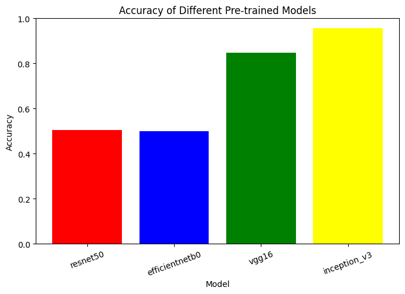

```python
#Visualize the accuracies using a bar chart
x = models
y = accuracies

plt.figure(figsize=(8, 5))
plt.bar(x, y, color=['red', 'blue', 'green', 'yellow'])
plt.xlabel("Model")
plt.ylabel("Accuracy")
plt.title("Accuracy of Different Pre-trained Models")
plt.ylim(0, 1)
plt.xticks(rotation=20)
plt.show()
```

# Part 3: Implementing and Modifying the U-Net architecture

Instructions:

1. Use the same U-net code provided in the module and change the IOU and prediction thresholds to 0.8 and retrain. Did you notice any change in the test prediction image? Please explain the change and the cause.
2. Now change only the test prediction threshold to 0.1, without retraining, what change did you see? Please explain the change and the cause.
3. Modify the U-Net architecture to increase the number of filters to 16. Then add Batchnormalization layers. You should Google this topic but here is how you can include it:  
   x = BatchNormalization()(x)  
   Add this expression to your downsampling block after the Conv2D blocks, in the bottleneck (again after the Conv2D block) and then in the upsampling block in the same way. You should see an improvement in your IOU. Note the improvement and explain why do you think it improved.

```python
!wget http://www.robots.ox.ac.uk/~vgg/data/pets/data/images.tar.gz
!wget http://www.robots.ox.ac.uk/~vgg/data/pets/data/annotations.tar.gz
!tar -xvzf images.tar.gz && tar -xvzf annotations.tar.gz
!rm  images/*.mat
```

[output not shown]

[output cut: 4946 more lines]

[output not shown]

```python
def image_generator(files, batch_size = 32, sz = (256, 256)):

  while True:

    #extract a random batch
    batch = np.random.choice(files, size = batch_size)

    #variables for collecting batches of inputs and outputs
    batch_x = []
    batch_y = []


    for f in batch:

        #get the masks. Note that masks are png files
        mask = Image.open(f'annotations/trimaps/{f[:-4]}.png')
        mask = np.array(mask.resize(sz))


        #preprocess the mask
        mask[mask >= 2] = 0
        mask[mask != 0 ] = 1

        batch_y.append(mask)

        #preprocess the raw images
        raw = Image.open(f'images/{f}')
        raw = raw.resize(sz)
        raw = np.array(raw)

        #check the number of channels because some of the images are RGBA or GRAY
        if len(raw.shape) == 2:
          raw = np.stack((raw,)*3, axis=-1)

        else:
          raw = raw[:,:,0:3]

        batch_x.append(raw)

    #preprocess a batch of images and masks
    batch_x = np.array(batch_x)/255.
    batch_y = np.array(batch_y)
    batch_y = np.expand_dims(batch_y,3)

    yield (batch_x, batch_y)
```

```python
batch_size = 32

all_files = os.listdir('images')
shuffle(all_files)

split = int(0.95 * len(all_files))

#split into training and testing
train_files = all_files[0:split]
test_files  = all_files[split:]

train_generator = image_generator(train_files, batch_size = batch_size)
test_generator  = image_generator(test_files, batch_size = batch_size)
```

```python
x, y= next(train_generator)
```

```python
def mean_iou(y_true, y_pred):
    yt0 = tf.cast(y_true[:,:,:,0], tf.float32)  # Cast to float32
    yp0 = tf.cast(y_pred[:,:,:,0] > 0.8, tf.float32)  # Cast to float32 #Changing to 0.8
    inter = tf.reduce_sum(tf.cast(tf.logical_and(tf.equal(yt0, 1), tf.equal(yp0, 1)), tf.float32))
    union = tf.reduce_sum(tf.cast(tf.add(yt0, yp0), tf.float32))
    iou = inter / tf.maximum(union, 1e-10)  # Prevent division by zero
    return iou
```

```python
def unet(sz = (256, 256, 3)):
  x = Input(sz)
  inputs = x

  #down sampling
  f = 16
  layers = []

  for i in range(0, 6):
    x = Conv2D(f, 3, activation='relu', padding='same') (x)
    x = Conv2D(f, 3, activation='relu', padding='same') (x)
    x = BatchNormalization()(x)
    layers.append(x)
    x = MaxPooling2D() (x)
    f = f*2
  ff2 = 64

  #bottleneck
  j = len(layers) - 1
  x = Conv2D(f, 3, activation='relu', padding='same') (x)
  x = Conv2D(f, 3, activation='relu', padding='same') (x)
  x = Conv2DTranspose(ff2, 2, strides=(2, 2), padding='same') (x)
  x = BatchNormalization()(x)
  x = Concatenate(axis=3)([x, layers[j]])
  j = j -1

  #upsampling
  for i in range(0, 5):
    ff2 = ff2//2
    f = f // 2
    x = Conv2D(f, 3, activation='relu', padding='same') (x)
    x = Conv2D(f, 3, activation='relu', padding='same') (x)
    x = Conv2DTranspose(ff2, 2, strides=(2, 2), padding='same') (x)
    x = BatchNormalization()(x)
    x = Concatenate(axis=3)([x, layers[j]])
    j = j -1


  #classification
  x = Conv2D(f, 3, activation='relu', padding='same') (x)
  x = Conv2D(f, 3, activation='relu', padding='same') (x)
  outputs = Conv2D(1, 1, activation='sigmoid') (x)

  #model creation
  model = Model(inputs=[inputs], outputs=[outputs])
  model.compile(optimizer = 'rmsprop', loss = 'binary_crossentropy', metrics = [mean_iou])

  return model
model = unet()
```

```python
def build_callbacks():
        checkpointer = ModelCheckpoint(filepath='unet.h5', verbose=0, save_best_only=True)
        callbacks = [checkpointer, PlotLearning()]
        return callbacks

# inheritance for training process plot
class PlotLearning(keras.callbacks.Callback):

    def on_train_begin(self, logs={}):
        self.i = 0
        self.x = []
        self.losses = []
        self.val_losses = []
        self.acc = []
        self.val_acc = []
        #self.fig = plt.figure()
        self.logs = []
    def on_epoch_end(self, epoch, logs={}):
        self.logs.append(logs)
        self.x.append(self.i)
        self.losses.append(logs.get('loss'))
        self.val_losses.append(logs.get('val_loss'))
        self.acc.append(logs.get('mean_iou'))
        self.val_acc.append(logs.get('val_mean_iou'))
        self.i += 1
        print('i=',self.i,'loss=',logs.get('loss'),'val_loss=',logs.get('val_loss'),'mean_iou=',logs.get('mean_iou'),'val_mean_iou=',logs.get('val_mean_iou'))

        #choose a random test image and preprocess
        path = np.random.choice(test_files)
        raw = Image.open(f'images/{path}')
        raw = np.array(raw.resize((256, 256)))/255.
        raw = raw[:,:,0:3]

        #predict the mask
        pred = model.predict(np.expand_dims(raw, 0))

        #mask post-processing
        msk  = pred.squeeze()
        msk = np.stack((msk,)*3, axis=-1)
        msk[msk >= 0.8] = 1 #Changing to 0.8
        msk[msk < 0.8] = 0 #Changing to 0.8

        #show the mask and the segmented image
        combined = np.concatenate([raw, msk, raw* msk], axis = 1)
        plt.axis('off')
        plt.imshow(combined)
        plt.show()
```

```
i= 1 loss= 0.41119644045829773 val_loss= 1.843084692955017 mean_iou= 0.1710810512304306 val_mean_iou= 0.2576806843280792
```

```
1/1 ━━━━━━━━━━━━━━━━━━━━ 2s 2s/step
```

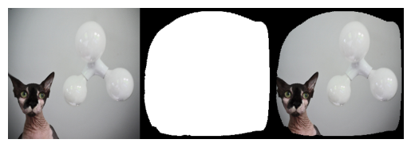

```
WARNING:absl:You are saving your model as an HDF5 file via `model.save()` or `keras.saving.save_model(model)`. This file format is considered legacy. We recommend using instead the native Keras format, e.g. `model.save('my_model.keras')` or `keras.saving.save_model(model, 'my_model.keras')`.
```

```
i= 2 loss= 0.256329208612442 val_loss= 0.3318820595741272 mean_iou= 0.3560205101966858 val_mean_iou= 0.39784374833106995
1/1 ━━━━━━━━━━━━━━━━━━━━ 0s 38ms/step
```

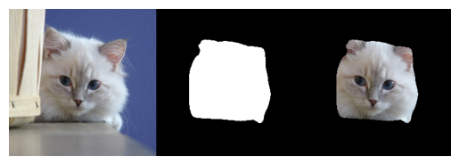

```
WARNING:absl:You are saving your model as an HDF5 file via `model.save()` or `keras.saving.save_model(model)`. This file format is considered legacy. We recommend using instead the native Keras format, e.g. `model.save('my_model.keras')` or `keras.saving.save_model(model, 'my_model.keras')`.
```

```
i= 3 loss= 0.2101421058177948 val_loss= 0.24403329193592072 mean_iou= 0.3865835666656494 val_mean_iou= 0.41878458857536316
1/1 ━━━━━━━━━━━━━━━━━━━━ 0s 37ms/step
```

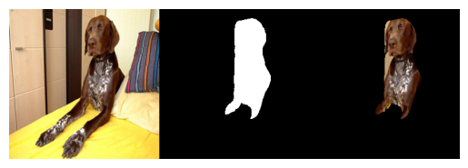

```
WARNING:absl:You are saving your model as an HDF5 file via `model.save()` or `keras.saving.save_model(model)`. This file format is considered legacy. We recommend using instead the native Keras format, e.g. `model.save('my_model.keras')` or `keras.saving.save_model(model, 'my_model.keras')`.
```

```
i= 4 loss= 0.18685470521450043 val_loss= 0.23104533553123474 mean_iou= 0.40374720096588135 val_mean_iou= 0.38272345066070557
1/1 ━━━━━━━━━━━━━━━━━━━━ 0s 38ms/step
```

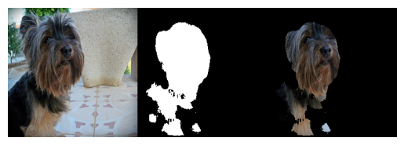

```
WARNING:absl:You are saving your model as an HDF5 file via `model.save()` or `keras.saving.save_model(model)`. This file format is considered legacy. We recommend using instead the native Keras format, e.g. `model.save('my_model.keras')` or `keras.saving.save_model(model, 'my_model.keras')`.
```

```
i= 5 loss= 0.16843721270561218 val_loss= 0.20669150352478027 mean_iou= 0.41465896368026733 val_mean_iou= 0.39095088839530945
1/1 ━━━━━━━━━━━━━━━━━━━━ 0s 39ms/step
```

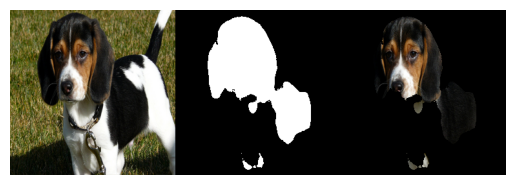

```
WARNING:absl:You are saving your model as an HDF5 file via `model.save()` or `keras.saving.save_model(model)`. This file format is considered legacy. We recommend using instead the native Keras format, e.g. `model.save('my_model.keras')` or `keras.saving.save_model(model, 'my_model.keras')`.
```

```
i= 6 loss= 0.1561128795146942 val_loss= 0.20536604523658752 mean_iou= 0.42039963603019714 val_mean_iou= 0.4190225303173065
1/1 ━━━━━━━━━━━━━━━━━━━━ 0s 38ms/step
```

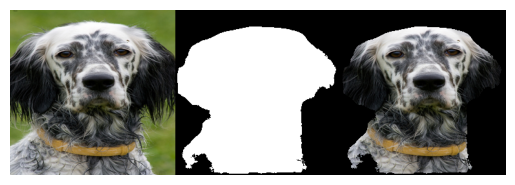

```
WARNING:absl:You are saving your model as an HDF5 file via `model.save()` or `keras.saving.save_model(model)`. This file format is considered legacy. We recommend using instead the native Keras format, e.g. `model.save('my_model.keras')` or `keras.saving.save_model(model, 'my_model.keras')`.
```

```
i= 7 loss= 0.14378874003887177 val_loss= 0.1746302992105484 mean_iou= 0.4274686276912689 val_mean_iou= 0.4287774860858917
1/1 ━━━━━━━━━━━━━━━━━━━━ 0s 43ms/step
```

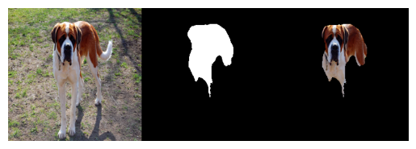

```
i= 8 loss= 0.13536173105239868 val_loss= 0.20127588510513306 mean_iou= 0.43289074301719666 val_mean_iou= 0.3989514410495758
1/1 ━━━━━━━━━━━━━━━━━━━━ 0s 37ms/step
```

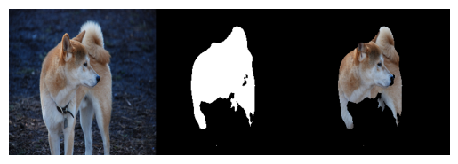

```
i= 9 loss= 0.13159358501434326 val_loss= 0.22511392831802368 mean_iou= 0.43386709690093994 val_mean_iou= 0.42209234833717346
1/1 ━━━━━━━━━━━━━━━━━━━━ 0s 37ms/step
```

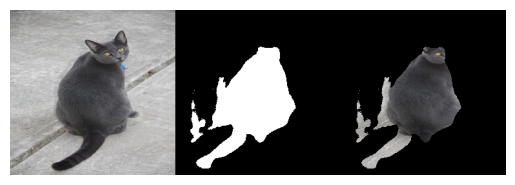

```
WARNING:absl:You are saving your model as an HDF5 file via `model.save()` or `keras.saving.save_model(model)`. This file format is considered legacy. We recommend using instead the native Keras format, e.g. `model.save('my_model.keras')` or `keras.saving.save_model(model, 'my_model.keras')`.
```

```
i= 10 loss= 0.1210203468799591 val_loss= 0.1630171686410904 mean_iou= 0.44001808762550354 val_mean_iou= 0.4088439643383026
1/1 ━━━━━━━━━━━━━━━━━━━━ 0s 41ms/step
```

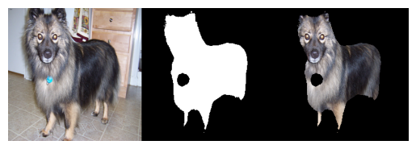

```
<keras.src.callbacks.history.History at 0x787c27e03f90>
```

```python
train_steps = len(train_files) //batch_size
test_steps = len(test_files) //batch_size
model.fit(train_generator,
                    epochs = 10, steps_per_epoch = train_steps,validation_data = test_generator, validation_steps = test_steps,
                    callbacks = build_callbacks(), verbose = 0)
```

```python
!wget http://r.ddmcdn.com/s_f/o_1/cx_462/cy_245/cw_1349/ch_1349/w_720/APL/uploads/2015/06/caturday-shutterstock_149320799.jpg -O test.jpg
```

```
--2025-06-15 22:20:20--  http://r.ddmcdn.com/s_f/o_1/cx_462/cy_245/cw_1349/ch_1349/w_720/APL/uploads/2015/06/caturday-shutterstock_149320799.jpg
Resolving r.ddmcdn.com (r.ddmcdn.com)... 108.157.254.110, 108.157.254.29, 108.157.254.93, ...
Connecting to r.ddmcdn.com (r.ddmcdn.com)|108.157.254.110|:80... connected.
HTTP request sent, awaiting response... 200 OK
Length: 63219 (62K) [image/jpeg]
Saving to: ‘test.jpg’


test.jpg              0%[                    ]       0  --.-KB/s
test.jpg            100%[===================>]  61.74K  --.-KB/s    in 0.003s

2025-06-15 22:20:20 (19.2 MB/s) - ‘test.jpg’ saved [63219/63219]
```

```
1/1 ━━━━━━━━━━━━━━━━━━━━ 0s 38ms/step
```

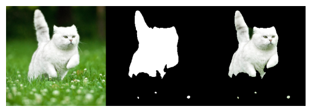

```python
raw = Image.open('test.jpg')
raw = np.array(raw.resize((256, 256)))/255.
raw = raw[:,:,0:3]

#predict the mask
pred = model.predict(np.expand_dims(raw, 0))

#mask post-processing
msk  = pred.squeeze()
msk = np.stack((msk,)*3, axis=-1)
msk[msk >= 0.1] = 1
msk[msk < 0.1] = 0

#show the mask and the segmented image
combined = np.concatenate([raw, msk, raw* msk], axis = 1)
plt.axis('off')
plt.imshow(combined)
plt.show()
```

# Observations

## The changes that I saw after moving the thresholds to 0.8 were not much in the test image. It is slightly less accurate than the module. This is due to there being a higher threshold for the model to predict it in the positive class

## Changing just the test threshold seems to have made it identify more than when it was at 0.8. This is because it was more often classifying more true positives

# Part 4: Functions for evaluating segmentation:

- IOU
- Precision
- Recall
- Dice Coefficient

Each of these functions should accept two parameters (images) and return the score

```python
#Function to calculate IOU
def calculate_iou(img1, img2):
    threshold = 0.5
    img1 = (img1 > threshold).astype(np.uint8)
    img2 = (img2 > threshold).astype(np.uint8)
    intersection = np.logical_and(img1, img2)
    union = np.logical_or(img1, img2)
    iou_score = np.sum(intersection) / np.sum(union)
    return iou_score
#Function to calculate percision
def calculate_precision(img1, img2):
    threshold = 0.5
    img1 = (img1 > threshold).astype(np.uint8)
    img2 = (img2 > threshold).astype(np.uint8)
    intersection = np.logical_and(img1, img2)
    precision_score = np.sum(intersection) / np.sum(img1)
    return precision_score
#Function to calculate recall
def calculate_recall(img1, img2):
    threshold = 0.5
    img1 = (img1 > threshold).astype(np.uint8)
    img2 = (img2 > threshold).astype(np.uint8)
    intersection = np.logical_and(img1, img2)
    recall_score = np.sum(intersection) / np.sum(img2)
    return recall_score
#function to calculate Dice Coefficient
def calculate_dice_coefficient(img1, img2):
    threshold = 0.5
    img1 = (img1 > threshold).astype(np.uint8)
    img2 = (img2 > threshold).astype(np.uint8)
    intersection = np.logical_and(img1, img2)
    dice_score = 2.0 * np.sum(intersection) / (np.sum(img1) + np.sum(img2))
    return dice_score
```

# Part 5: Evaluating Segmentation Performance

1. Call the last 4 functions with actual_mask1 and pred_mask1
2. Calculate and print all the scores.

```python
#Load in the images
actual_mask1 = Image.open('actual_mask1.png')
pred_mask1 = Image.open('pred_mask1.png')

#Resize images to same size
actual_mask1 = actual_mask1.resize((256, 256))
pred_mask1 = pred_mask1.resize((256, 256))

#Run through the functions and print the scores
print("IOU Score:", calculate_iou(np.array(actual_mask1), np.array(pred_mask1)))
print("Precision Score:", calculate_precision(np.array(actual_mask1), np.array(pred_mask1)))
print("Recall Score:", calculate_recall(np.array(actual_mask1), np.array(pred_mask1)))
print("Dice Coefficient Score:", calculate_dice_coefficient(np.array(actual_mask1), np.array(pred_mask1)))
```

```
IOU Score: 0.9169617162291794
Precision Score: 1.0
Recall Score: 0.9169617162291794
Dice Coefficient Score: 0.9566823463046702
```

# Submission Instructions

1. Perform a Restart and Run All by clicking **Tools > Restart session and run all**.
2. Copy the link to your notebook by clicking **Share > Copy Link**.
3. Paste the copied link into the `notebook_url` field in the [Notebook Renderer](https://colab.research.google.com/drive/1CJTipys46ldZxJFwnt7XbdjQUfkmoXeU?usp=sharing) tool and then execute the cell to render the notebook.
4. The Notebook Renderer will open up a save file dialog. Save the resulting HTML file yo your local machine.
5. Submit the HTML file to Canvas.